# Risk Factor Analysis

## Outcome Variable

**Outcome Variable:** wasted

## Predictor Variables

**Intervention Variable:** fhtcm

**Adjustment Set:**

unadjusted

## Stratifying Variables

The analysis was stratified on these variable(s):

- agecat
- studyid
- country

## Data Summary

| agecat | studyid | country | fhtcm | wasted | n_cell | n | outcome_variable |
| --- | --- | --- | --- | --- | --- | --- | --- |
| Birth | ki1000304b-SAS-CompFeed | INDIA | >=167 cm | 0 | 286 | 657 | wasted |
| Birth | ki1000304b-SAS-CompFeed | INDIA | >=167 cm | 1 | 26 | 657 | wasted |
| Birth | ki1000304b-SAS-CompFeed | INDIA | <162 cm | 0 | 153 | 657 | wasted |
| Birth | ki1000304b-SAS-CompFeed | INDIA | <162 cm | 1 | 6 | 657 | wasted |
| Birth | ki1000304b-SAS-CompFeed | INDIA | [162-167) cm | 0 | 164 | 657 | wasted |
| Birth | ki1000304b-SAS-CompFeed | INDIA | [162-167) cm | 1 | 22 | 657 | wasted |
| Birth | ki1101329-Keneba | GAMBIA | >=167 cm | 0 | 550 | 1114 | wasted |
| Birth | ki1101329-Keneba | GAMBIA | >=167 cm | 1 | 183 | 1114 | wasted |
| Birth | ki1101329-Keneba | GAMBIA | <162 cm | 0 | 58 | 1114 | wasted |
| Birth | ki1101329-Keneba | GAMBIA | <162 cm | 1 | 25 | 1114 | wasted |
| Birth | ki1101329-Keneba | GAMBIA | [162-167) cm | 0 | 228 | 1114 | wasted |
| Birth | ki1101329-Keneba | GAMBIA | [162-167) cm | 1 | 70 | 1114 | wasted |
| Birth | ki1119695-PROBIT | BELARUS | >=167 cm | 0 | 9274 | 12474 | wasted |
| Birth | ki1119695-PROBIT | BELARUS | >=167 cm | 1 | 2410 | 12474 | wasted |
| Birth | ki1119695-PROBIT | BELARUS | <162 cm | 0 | 130 | 12474 | wasted |
| Birth | ki1119695-PROBIT | BELARUS | <162 cm | 1 | 38 | 12474 | wasted |
| Birth | ki1119695-PROBIT | BELARUS | [162-167) cm | 0 | 478 | 12474 | wasted |
| Birth | ki1119695-PROBIT | BELARUS | [162-167) cm | 1 | 144 | 12474 | wasted |
| Birth | ki1135781-COHORTS | GUATEMALA | >=167 cm | 0 | 22 | 192 | wasted |
| Birth | ki1135781-COHORTS | GUATEMALA | >=167 cm | 1 | 4 | 192 | wasted |
| Birth | ki1135781-COHORTS | GUATEMALA | <162 cm | 0 | 92 | 192 | wasted |
| Birth | ki1135781-COHORTS | GUATEMALA | <162 cm | 1 | 20 | 192 | wasted |
| Birth | ki1135781-COHORTS | GUATEMALA | [162-167) cm | 0 | 42 | 192 | wasted |
| Birth | ki1135781-COHORTS | GUATEMALA | [162-167) cm | 1 | 12 | 192 | wasted |
| 6 months | ki1000304b-SAS-CompFeed | INDIA | >=167 cm | 0 | 332 | 807 | wasted |
| 6 months | ki1000304b-SAS-CompFeed | INDIA | >=167 cm | 1 | 38 | 807 | wasted |
| 6 months | ki1000304b-SAS-CompFeed | INDIA | <162 cm | 0 | 170 | 807 | wasted |
| 6 months | ki1000304b-SAS-CompFeed | INDIA | <162 cm | 1 | 23 | 807 | wasted |
| 6 months | ki1000304b-SAS-CompFeed | INDIA | [162-167) cm | 0 | 212 | 807 | wasted |
| 6 months | ki1000304b-SAS-CompFeed | INDIA | [162-167) cm | 1 | 32 | 807 | wasted |
| 6 months | ki1000304b-SAS-FoodSuppl | INDIA | >=167 cm | 0 | 88 | 371 | wasted |
| 6 months | ki1000304b-SAS-FoodSuppl | INDIA | >=167 cm | 1 | 14 | 371 | wasted |
| 6 months | ki1000304b-SAS-FoodSuppl | INDIA | <162 cm | 0 | 115 | 371 | wasted |
| 6 months | ki1000304b-SAS-FoodSuppl | INDIA | <162 cm | 1 | 33 | 371 | wasted |
| 6 months | ki1000304b-SAS-FoodSuppl | INDIA | [162-167) cm | 0 | 101 | 371 | wasted |
| 6 months | ki1000304b-SAS-FoodSuppl | INDIA | [162-167) cm | 1 | 20 | 371 | wasted |
| 6 months | ki1101329-Keneba | GAMBIA | >=167 cm | 0 | 923 | 1510 | wasted |
| 6 months | ki1101329-Keneba | GAMBIA | >=167 cm | 1 | 56 | 1510 | wasted |
| 6 months | ki1101329-Keneba | GAMBIA | <162 cm | 0 | 104 | 1510 | wasted |
| 6 months | ki1101329-Keneba | GAMBIA | <162 cm | 1 | 9 | 1510 | wasted |
| 6 months | ki1101329-Keneba | GAMBIA | [162-167) cm | 0 | 397 | 1510 | wasted |
| 6 months | ki1101329-Keneba | GAMBIA | [162-167) cm | 1 | 21 | 1510 | wasted |
| 6 months | ki1119695-PROBIT | BELARUS | >=167 cm | 0 | 11053 | 11892 | wasted |
| 6 months | ki1119695-PROBIT | BELARUS | >=167 cm | 1 | 90 | 11892 | wasted |
| 6 months | ki1119695-PROBIT | BELARUS | <162 cm | 0 | 155 | 11892 | wasted |
| 6 months | ki1119695-PROBIT | BELARUS | <162 cm | 1 | 1 | 11892 | wasted |
| 6 months | ki1119695-PROBIT | BELARUS | [162-167) cm | 0 | 592 | 11892 | wasted |
| 6 months | ki1119695-PROBIT | BELARUS | [162-167) cm | 1 | 1 | 11892 | wasted |
| 6 months | ki1135781-COHORTS | GUATEMALA | >=167 cm | 0 | 44 | 336 | wasted |
| 6 months | ki1135781-COHORTS | GUATEMALA | >=167 cm | 1 | 0 | 336 | wasted |
| 6 months | ki1135781-COHORTS | GUATEMALA | <162 cm | 0 | 190 | 336 | wasted |
| 6 months | ki1135781-COHORTS | GUATEMALA | <162 cm | 1 | 8 | 336 | wasted |
| 6 months | ki1135781-COHORTS | GUATEMALA | [162-167) cm | 0 | 89 | 336 | wasted |
| 6 months | ki1135781-COHORTS | GUATEMALA | [162-167) cm | 1 | 5 | 336 | wasted |
| 24 months | ki1101329-Keneba | GAMBIA | >=167 cm | 0 | 743 | 1298 | wasted |
| 24 months | ki1101329-Keneba | GAMBIA | >=167 cm | 1 | 80 | 1298 | wasted |
| 24 months | ki1101329-Keneba | GAMBIA | <162 cm | 0 | 79 | 1298 | wasted |
| 24 months | ki1101329-Keneba | GAMBIA | <162 cm | 1 | 17 | 1298 | wasted |
| 24 months | ki1101329-Keneba | GAMBIA | [162-167) cm | 0 | 344 | 1298 | wasted |
| 24 months | ki1101329-Keneba | GAMBIA | [162-167) cm | 1 | 35 | 1298 | wasted |
| 24 months | ki1119695-PROBIT | BELARUS | >=167 cm | 0 | 3353 | 3610 | wasted |
| 24 months | ki1119695-PROBIT | BELARUS | >=167 cm | 1 | 35 | 3610 | wasted |
| 24 months | ki1119695-PROBIT | BELARUS | <162 cm | 0 | 50 | 3610 | wasted |
| 24 months | ki1119695-PROBIT | BELARUS | <162 cm | 1 | 2 | 3610 | wasted |
| 24 months | ki1119695-PROBIT | BELARUS | [162-167) cm | 0 | 168 | 3610 | wasted |
| 24 months | ki1119695-PROBIT | BELARUS | [162-167) cm | 1 | 2 | 3610 | wasted |
| 24 months | ki1135781-COHORTS | GUATEMALA | >=167 cm | 0 | 69 | 532 | wasted |
| 24 months | ki1135781-COHORTS | GUATEMALA | >=167 cm | 1 | 3 | 532 | wasted |
| 24 months | ki1135781-COHORTS | GUATEMALA | <162 cm | 0 | 292 | 532 | wasted |
| 24 months | ki1135781-COHORTS | GUATEMALA | <162 cm | 1 | 19 | 532 | wasted |
| 24 months | ki1135781-COHORTS | GUATEMALA | [162-167) cm | 0 | 140 | 532 | wasted |
| 24 months | ki1135781-COHORTS | GUATEMALA | [162-167) cm | 1 | 9 | 532 | wasted |

The following strata were considered:

- agecat: 24 months, studyid: ki1101329-Keneba, country: GAMBIA
- agecat: 24 months, studyid: ki1119695-PROBIT, country: BELARUS
- agecat: 24 months, studyid: ki1135781-COHORTS, country: GUATEMALA
- agecat: 6 months, studyid: ki1000304b-SAS-CompFeed, country: INDIA
- agecat: 6 months, studyid: ki1000304b-SAS-FoodSuppl, country: INDIA
- agecat: 6 months, studyid: ki1101329-Keneba, country: GAMBIA
- agecat: 6 months, studyid: ki1119695-PROBIT, country: BELARUS
- agecat: 6 months, studyid: ki1135781-COHORTS, country: GUATEMALA
- agecat: Birth, studyid: ki1000304b-SAS-CompFeed, country: INDIA
- agecat: Birth, studyid: ki1101329-Keneba, country: GAMBIA
- agecat: Birth, studyid: ki1119695-PROBIT, country: BELARUS
- agecat: Birth, studyid: ki1135781-COHORTS, country: GUATEMALA

### Dropped Strata

Some strata were dropped due to rare outcomes:

- agecat: Birth, studyid: ki1135781-COHORTS, country: GUATEMALA
- agecat: 6 months, studyid: ki1119695-PROBIT, country: BELARUS
- agecat: 6 months, studyid: ki1135781-COHORTS, country: GUATEMALA
- agecat: 24 months, studyid: ki1119695-PROBIT, country: BELARUS
- agecat: 24 months, studyid: ki1135781-COHORTS, country: GUATEMALA

## Methods Detail

We’re interested in the causal parameters $E[Y_a]$ for all values of $a \in \mathcal{A}$. These parameters represent the mean outcome if, possibly contrary to fact, we intervened to set all units to have $A=a$. Under the randomization and positivity assumptions, these are identified by the statistical parameters $\psi_a=E_W[E_{Y|A,W}(Y|A=a,W)]$. In addition, we’re interested in the mean of $Y$, $E[Y]$ under no intervention (the observed mean). We will estimate these parameters by using SuperLearner to fit the relevant likelihood factors – $E_{Y|A,W}(Y|A=a,W)$ and $p(A=a|W)$, and then updating our likelihood fit using a joint TMLE.

For unadjusted analyses ($W=\{\}$), initial likelihoods were estimated using Lrnr_glm to estimate the simple $E(Y|A)$ and Lrnr_mean to estimate $p(A)$. For adjusted analyses, a small library containing Lrnr_glmnet, Lrnr_xgboost, and Lrnr_mean was used.

Having estimated these parameters, we will then use the delta method to estimate relative risks and attributable risks relative to a prespecified baseline level of $A$.

# Results Detail

## Results Plots

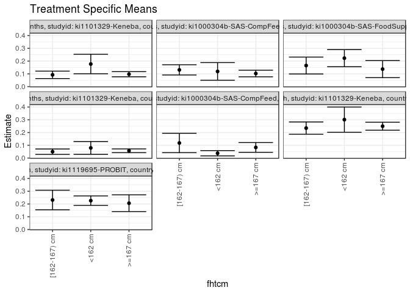

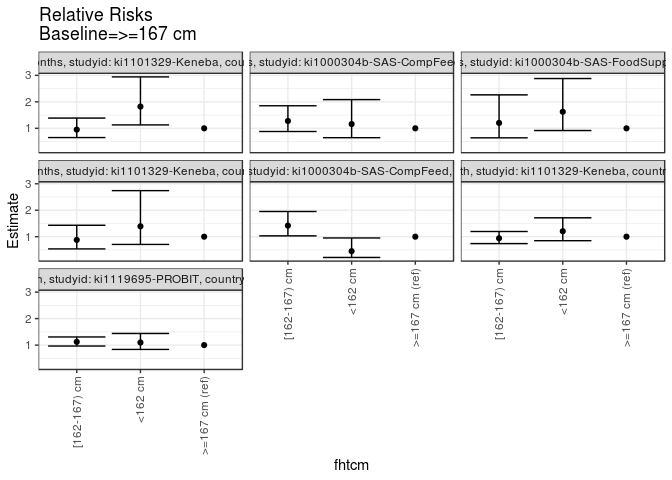

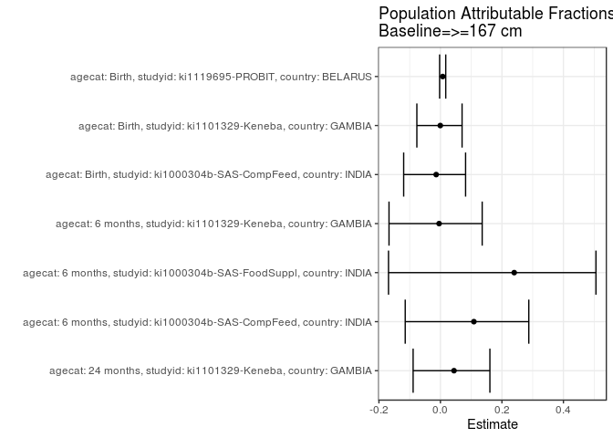

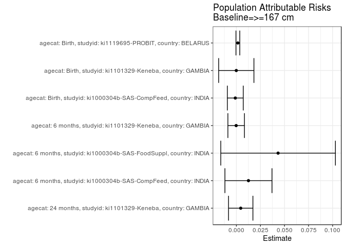

## Results Table

### Parameter: TSM

| agecat | studyid | country | intervention_level | baseline_level | estimate | ci_lower | ci_upper |
| --- | --- | --- | --- | --- | --- | --- | --- |
| Birth | ki1000304b-SAS-CompFeed | INDIA | >=167 cm | NA | 0.0833333 | 0.0448740 | 0.1217926 |
| Birth | ki1000304b-SAS-CompFeed | INDIA | <162 cm | NA | 0.0377358 | 0.0169272 | 0.0585445 |
| Birth | ki1000304b-SAS-CompFeed | INDIA | [162-167) cm | NA | 0.1182796 | 0.0425886 | 0.1939705 |
| Birth | ki1101329-Keneba | GAMBIA | >=167 cm | NA | 0.2496589 | 0.2183121 | 0.2810058 |
| Birth | ki1101329-Keneba | GAMBIA | <162 cm | NA | 0.3012048 | 0.2024610 | 0.3999486 |
| Birth | ki1101329-Keneba | GAMBIA | [162-167) cm | NA | 0.2348993 | 0.1867450 | 0.2830536 |
| Birth | ki1119695-PROBIT | BELARUS | >=167 cm | NA | 0.2062650 | 0.1405802 | 0.2719498 |
| Birth | ki1119695-PROBIT | BELARUS | <162 cm | NA | 0.2261905 | 0.1890084 | 0.2633726 |
| Birth | ki1119695-PROBIT | BELARUS | [162-167) cm | NA | 0.2315113 | 0.1547098 | 0.3083128 |
| 6 months | ki1000304b-SAS-CompFeed | INDIA | >=167 cm | NA | 0.1027027 | 0.0768935 | 0.1285119 |
| 6 months | ki1000304b-SAS-CompFeed | INDIA | <162 cm | NA | 0.1191710 | 0.0499344 | 0.1884076 |
| 6 months | ki1000304b-SAS-CompFeed | INDIA | [162-167) cm | NA | 0.1311475 | 0.0911059 | 0.1711892 |
| 6 months | ki1000304b-SAS-FoodSuppl | INDIA | >=167 cm | NA | 0.1372549 | 0.0703837 | 0.2041261 |
| 6 months | ki1000304b-SAS-FoodSuppl | INDIA | <162 cm | NA | 0.2229730 | 0.1558227 | 0.2901232 |
| 6 months | ki1000304b-SAS-FoodSuppl | INDIA | [162-167) cm | NA | 0.1652893 | 0.0990170 | 0.2315615 |
| 6 months | ki1101329-Keneba | GAMBIA | >=167 cm | NA | 0.0572012 | 0.0426496 | 0.0717529 |
| 6 months | ki1101329-Keneba | GAMBIA | <162 cm | NA | 0.0796460 | 0.0297102 | 0.1295818 |
| 6 months | ki1101329-Keneba | GAMBIA | [162-167) cm | NA | 0.0502392 | 0.0292917 | 0.0711867 |
| 24 months | ki1101329-Keneba | GAMBIA | >=167 cm | NA | 0.0972053 | 0.0769586 | 0.1174521 |
| 24 months | ki1101329-Keneba | GAMBIA | <162 cm | NA | 0.1770833 | 0.1006916 | 0.2534751 |
| 24 months | ki1101329-Keneba | GAMBIA | [162-167) cm | NA | 0.0923483 | 0.0631895 | 0.1215071 |

### Parameter: E(Y)

| agecat | studyid | country | intervention_level | baseline_level | estimate | ci_lower | ci_upper |
| --- | --- | --- | --- | --- | --- | --- | --- |
| Birth | ki1000304b-SAS-CompFeed | INDIA | NA | NA | 0.0821918 | 0.0448621 | 0.1195215 |
| Birth | ki1101329-Keneba | GAMBIA | NA | NA | 0.2495512 | 0.2241273 | 0.2749750 |
| Birth | ki1119695-PROBIT | BELARUS | NA | NA | 0.2077922 | 0.1422720 | 0.2733124 |
| 6 months | ki1000304b-SAS-CompFeed | INDIA | NA | NA | 0.1152416 | 0.0868962 | 0.1435870 |
| 6 months | ki1000304b-SAS-FoodSuppl | INDIA | NA | NA | 0.1805930 | 0.1413965 | 0.2197895 |
| 6 months | ki1101329-Keneba | GAMBIA | NA | NA | 0.0569536 | 0.0452605 | 0.0686468 |
| 24 months | ki1101329-Keneba | GAMBIA | NA | NA | 0.1016949 | 0.0852459 | 0.1181439 |

### Parameter: RR

| agecat | studyid | country | intervention_level | baseline_level | estimate | ci_lower | ci_upper |
| --- | --- | --- | --- | --- | --- | --- | --- |
| Birth | ki1000304b-SAS-CompFeed | INDIA | >=167 cm | >=167 cm | 1.0000000 | 1.0000000 | 1.000000 |
| Birth | ki1000304b-SAS-CompFeed | INDIA | <162 cm | >=167 cm | 0.4528302 | 0.2154344 | 0.951822 |
| Birth | ki1000304b-SAS-CompFeed | INDIA | [162-167) cm | >=167 cm | 1.4193548 | 1.0317831 | 1.952511 |
| Birth | ki1101329-Keneba | GAMBIA | >=167 cm | >=167 cm | 1.0000000 | 1.0000000 | 1.000000 |
| Birth | ki1101329-Keneba | GAMBIA | <162 cm | >=167 cm | 1.2064652 | 0.8492881 | 1.713857 |
| Birth | ki1101329-Keneba | GAMBIA | [162-167) cm | >=167 cm | 0.9408809 | 0.7398306 | 1.196567 |
| Birth | ki1119695-PROBIT | BELARUS | >=167 cm | >=167 cm | 1.0000000 | 1.0000000 | 1.000000 |
| Birth | ki1119695-PROBIT | BELARUS | <162 cm | >=167 cm | 1.0966015 | 0.8357668 | 1.438840 |
| Birth | ki1119695-PROBIT | BELARUS | [162-167) cm | >=167 cm | 1.1223973 | 0.9642426 | 1.306492 |
| 6 months | ki1000304b-SAS-CompFeed | INDIA | >=167 cm | >=167 cm | 1.0000000 | 1.0000000 | 1.000000 |
| 6 months | ki1000304b-SAS-CompFeed | INDIA | <162 cm | >=167 cm | 1.1603490 | 0.6458133 | 2.084828 |
| 6 months | ki1000304b-SAS-CompFeed | INDIA | [162-167) cm | >=167 cm | 1.2769629 | 0.8805208 | 1.851897 |
| 6 months | ki1000304b-SAS-FoodSuppl | INDIA | >=167 cm | >=167 cm | 1.0000000 | 1.0000000 | 1.000000 |
| 6 months | ki1000304b-SAS-FoodSuppl | INDIA | <162 cm | >=167 cm | 1.6245174 | 0.9161651 | 2.880547 |
| 6 months | ki1000304b-SAS-FoodSuppl | INDIA | [162-167) cm | >=167 cm | 1.2042503 | 0.6407500 | 2.263314 |
| 6 months | ki1101329-Keneba | GAMBIA | >=167 cm | >=167 cm | 1.0000000 | 1.0000000 | 1.000000 |
| 6 months | ki1101329-Keneba | GAMBIA | <162 cm | >=167 cm | 1.3923831 | 0.7077955 | 2.739111 |
| 6 months | ki1101329-Keneba | GAMBIA | [162-167) cm | >=167 cm | 0.8782895 | 0.5389064 | 1.431403 |
| 24 months | ki1101329-Keneba | GAMBIA | >=167 cm | >=167 cm | 1.0000000 | 1.0000000 | 1.000000 |
| 24 months | ki1101329-Keneba | GAMBIA | <162 cm | >=167 cm | 1.8217448 | 1.1283469 | 2.941253 |
| 24 months | ki1101329-Keneba | GAMBIA | [162-167) cm | >=167 cm | 0.9500330 | 0.6508220 | 1.386804 |

### Parameter: PAR

| agecat | studyid | country | intervention_level | baseline_level | estimate | ci_lower | ci_upper |
| --- | --- | --- | --- | --- | --- | --- | --- |
| Birth | ki1000304b-SAS-CompFeed | INDIA | >=167 cm | NA | -0.0011416 | -0.0094022 | 0.0071191 |
| Birth | ki1101329-Keneba | GAMBIA | >=167 cm | NA | -0.0001078 | -0.0184349 | 0.0182193 |
| Birth | ki1119695-PROBIT | BELARUS | >=167 cm | NA | 0.0015272 | -0.0004557 | 0.0035102 |
| 6 months | ki1000304b-SAS-CompFeed | INDIA | >=167 cm | NA | 0.0125389 | -0.0119135 | 0.0369913 |
| 6 months | ki1000304b-SAS-FoodSuppl | INDIA | >=167 cm | NA | 0.0433381 | -0.0162376 | 0.1029138 |
| 6 months | ki1101329-Keneba | GAMBIA | >=167 cm | NA | -0.0002476 | -0.0088444 | 0.0083492 |
| 24 months | ki1101329-Keneba | GAMBIA | >=167 cm | NA | 0.0044896 | -0.0081858 | 0.0171650 |

### Parameter: PAF

| agecat | studyid | country | intervention_level | baseline_level | estimate | ci_lower | ci_upper |
| --- | --- | --- | --- | --- | --- | --- | --- |
| Birth | ki1000304b-SAS-CompFeed | INDIA | >=167 cm | NA | -0.0138889 | -0.1195659 | 0.0818131 |
| Birth | ki1101329-Keneba | GAMBIA | >=167 cm | NA | -0.0004319 | -0.0766348 | 0.0703776 |
| Birth | ki1119695-PROBIT | BELARUS | >=167 cm | NA | 0.0073498 | -0.0026729 | 0.0172723 |
| 6 months | ki1000304b-SAS-CompFeed | INDIA | >=167 cm | NA | 0.1088056 | -0.1145182 | 0.2873804 |
| 6 months | ki1000304b-SAS-FoodSuppl | INDIA | >=167 cm | NA | 0.2399766 | -0.1688644 | 0.5058147 |
| 6 months | ki1101329-Keneba | GAMBIA | >=167 cm | NA | -0.0043471 | -0.1672214 | 0.1357996 |
| 24 months | ki1101329-Keneba | GAMBIA | >=167 cm | NA | 0.0441474 | -0.0888027 | 0.1608635 |